# Parameter Estimation Of Mizer

Initialization

```r
library(mizer)
library(FME)
library(ggplot2)
library(reshape2)
library(deSolve)
library(ggplot2)
library(grid)
library(methods)
library(plyr)
library(reshape2)
library("plot3D")
library(rgl)
library("plot3Drgl")
library(optimx)
set.seed(123)
```

This is the second part of the initialization code. If this does not run in Rmd it might help to paste it into a script file, or the console, and run it there.

```r
params_data <- read.csv("./vignettes/NS_species_params.csv")
```

[output not shown]

First we define `model` function that takes in a parameter vector $\theta = (\theta_0,\theta_1,..,\theta_N)= (\log_{10}(\kappa), R_{max.1},..,R_{max.N}),$ and outputs a matrix $m(\theta) \in \mathbb{R}^{T \times N},$ where $N$ is the number of species, and $T$ is the number of time units which our population dynamics are run over. Here $m(\theta)_{t,i}$ is the log (base 10) of the total biomass of species $i \in \{1,..,N\}$ which was fished during year $t.$ This is obtained from our mizer model by first running `sim`, and then obtaining the catch data using `getYield`.

We also use time series information $Y \in \mathbb{R}^{T \times N},$ such that $Y_{t,i}$ is the log (base 10) of the total biomass of species $i \in \{1,..,N\}$ which was fished during year $t.$ Although we treat $Y$ as empirical data, we actually generate it in this sample, by setting $Y_{t,i} = m(\theta ^*)_{t,i} + \epsilon,$ where $\epsilon \in N(0,\sigma^2)$ where $\sigma$ is the standard deviation `mysd` we use to generate the measurement noise, and $\theta^*$ is our special choice of parameters, `mypar`, which corresponds to the parameter choice used in Mizer’s default North sea model.

We shall make a `gdplot()` based procedure to allow us to visualize such time series:

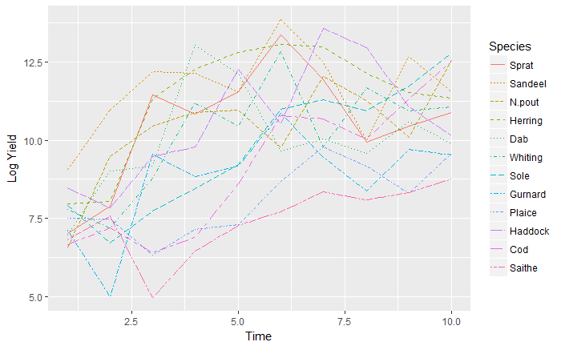

```r
show_time_series <- function(dataa =Y){
  y <- dataa
  #return(ggplot(ym) + geom_line(aes(x=time,y=value, colour=Species, linetype=Species)) + scale_y_continuous(trans="log10", name="Log Yield") + scale_x_continuous(name="Time"))
  return(ggplot(ym) + geom_line(aes(x=time,y=value, colour=Species, linetype=Species)) + scale_y_continuous( name="Log Yield") + scale_x_continuous(name="Time"))
  #return(ggplot(ym) + geom_point(aes(x=time,y=value, colour=Species, pointtype=Species)) + scale_y_continuous( name="Log Yield") + scale_x_continuous(name="Time"))
  }
show_time_series(Y)
```

We can see that there is quite a lot of measurement noise by comparing with the corresponding error free time series:

[output not shown]

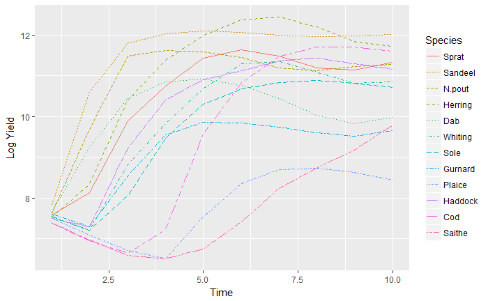

```r
show_time_series(model(mypar))
```

We shall investigate the minima of this cost function over the entire parameter space, before restricting our attention to a subspace. The actual parameter value used to generate the data was `mypar`.

```r
mypar
```

```
 [1] 11.00000 11.86806 11.61278 13.02119 12.04532 10.04922 11.73878 10.58771 12.21748
[10] 14.61066 12.26482  9.91698 11.04922
```

I believe this run stops at the nearby local minimum. Our results at least verify it is a fixed point of `optim`.

```r
myOP$par
```

```
 [1] 10.994953 11.949054 11.667868 12.694754 11.982921 10.349112 12.036479 17.755818
 [9] 11.803909 14.610835 12.917818  9.501727  7.777690
```

```r
myOP2$par
```

```
 [1] 10.994946 11.949052 11.667867 12.694755 11.982920 10.349114 12.036480 17.755822
 [9] 11.803909 14.610835 12.917818  9.501728  7.777691
```

Let us start our optimization algorithm from a different point.

```r
diffOP <- optim(fn = fish_model_cost, par=rep(9, length(mypar)),YY=Y, sd=mysd, method="BFGS")
diffOP2 <- optim(fn = fish_model_cost, par=diffOP$par,YY=Y, sd=mysd, method="BFGS")
```

In this case optim converges to a different fixed point, suggesting that our likelihood function is multimodal:

```r
diffOP$par
```

```
 [1] 10.892282 12.076399 11.729103 14.352759 21.926239 10.138359 11.502142 17.485690
 [9] 14.879883  8.531762 13.080173  9.074185 -6.358644
```

```r
diffOP2$par
```

```
 [1] 10.892279 12.076400 11.729101 14.352759 21.926239 10.138360 11.502140 17.485691
 [9] 14.879886  8.531762 13.080172  9.074184 -6.358644
```

Let us compare the model costs at `mypar`, the optima `myOP$par` near `mypar`, the alternative starting point `rep(9, length(mypar))` and the fixed point `diffOP$par` which `optim` moves this alternative starting point to:

```r
ans <- c(fish_model_cost(par=mypar),
  fish_model_cost(par=myOP$par),
  fish_model_cost(par=rep(9, length(mypar))),
  fish_model_cost(par=diffOP$par))
```

```r
ans
```

```
[1]  95.22878  87.55349 824.10314 114.51275
```

For simplicity, during an initial investigation, we stall take all parameter values as fixed except for the log carrying capacity $\log_{10} (\kappa)$ and log of $R_{max.1},$ which we shall consider to be parameters that must be fitted. We write another model cost function, `fish_model_res` with restricted inputs to accomplish this:

```r
fish_model_res <- function(par = mypar[1:2]){
  usedpar <- mypar
  usedpar[1:2] <- par
  return(fish_model_cost(usedpar))
}
```

We wish to plot the likelihood surface that’s height above a parameter point $(\log_{10} (\kappa),R_{max.1})$ is proportional to $p(Y|(\kappa),R_{max.1}))$. In order to achieve this we start by generating the time series model outputs for many parameter points on a 2D grid:

Note this chunk below takes a long time to run, and it is recommended to use the next chunk instead, to load the data rather than generating it:

```r
dp <- 0.1
log_carrying_capacity <- seq(10,12,by=dp)
log_r_max <- seq(10,13,by=dp)
time_pts <- as.numeric(rownames(Y))

# make array to store time series data for many points
RD <- array(0,c(length(log_carrying_capacity),length(log_r_max),length(time_pts),dim(Y)[2]))
for (i in (1:length(log_carrying_capacity))){
  for (j in (1:length(log_r_max))){
    usedpar <- mypar
    usedpar[1:2] <- c(log_carrying_capacity[i],log_r_max[j])
    RD[i,j, ,] <- model(usedpar)
  }
}
```

It is faster just to load these time series as precomputed data. Better paste this code in to the console in order to run it:

```r
load("EvolutionData2.RData")
log_carrying_capacity <- EvolutionData2$log_carrying_capacity
log_r_max <- EvolutionData2$log_r_max
RDC <- EvolutionData2$RDC
RD <- EvolutionData2$RD
```

We can use these time series to compute the model cost of our grid points

```r
time_series_to_cost <- function(timedata=Y,YY=Y, sd=mysd){
  return(sum((timedata-YY)^2/(sd^2)))
}
RDC <- array(0, c(length(log_carrying_capacity),length(log_r_max)))
for (i in (1:length(log_carrying_capacity))){
  for (j in (1:length(log_r_max))){
    RDC[i,j] <- time_series_to_cost(timedata=RD[i,j, ,],YY=Y, sd=mysd)
  }
}
#EvolutionData2 <- list(log_carrying_capacity, log_r_max, time_pts, RD, RDC)
```

We can use this data to draw our likelihood surface, and we see it i does indeed have a maximum at the parameter values underlying the data $Y.$

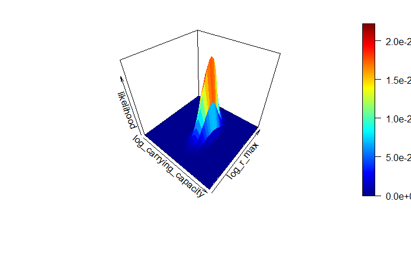

```r
persp3D(x=log_carrying_capacity, y=log_r_max, z=exp(-RDC/2),xlab = "log_carrying_capacity",
        ylab = "log_r_max", zlab = "likelihood")
```

The position of the maximum is easier to see using a contour plot:

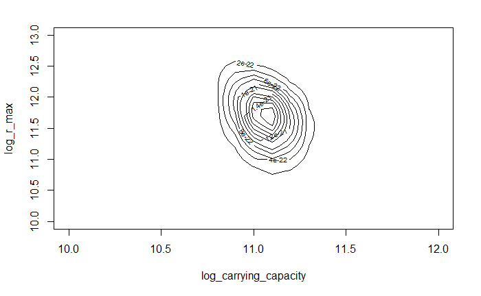

```r
contour(x=log_carrying_capacity, y=log_r_max, z=exp(-RDC/2),xlab = "log_carrying_capacity",
        ylab = "log_r_max")
```

Let us run our MCMC algorithm in this case:

```r
MCMC <- modMCMC(f = fish_model_res, p = c(12,7),
                niter = 100, jump = 0.1, updatecov = 10, lower=c(0.1,0.1),
                upper = c(20,20))
summary(MCMC)
```

The trace on the MCMC shows us how well it is exploring the parameter space:

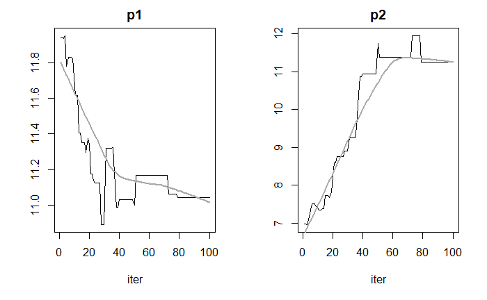

```r
plot(MCMC)
```

We can also examine a histogram showing the distribution of samples of the MCMC:

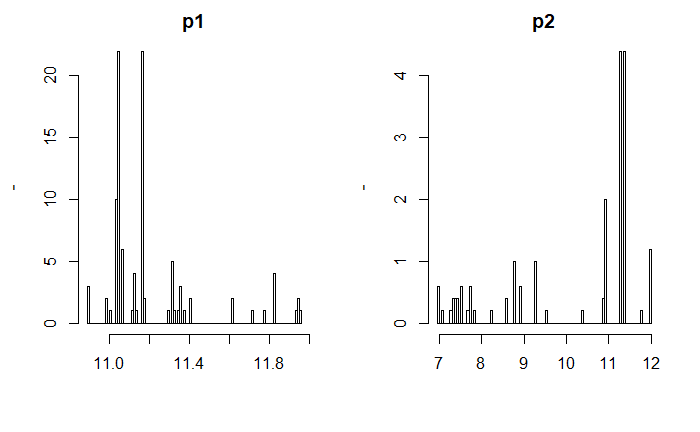

```r
hist(MCMC)
```

Now we will use the old model run data, together with the a new time series made up by a different model. Essentially we changed the settings we used to generate the data, so that the true generator lies outside the considered model space. Despite this we shall attempt to generate a likelihood surface:

```r
#load("EvolutionData2.RData")
log_carrying_capacity <- EvolutionData2$log_carrying_capacity
RDC <- EvolutionData2$RDC
RD <- EvolutionData2$RD
mysd2 <- 1
mypar2 <- mypar
mypar2[3:length(mypar2)] <- rep(min(mypar),(length(mypar2)-2))
mypar2
```

```
 [1] 11.00000 11.86806  9.91698  9.91698  9.91698  9.91698  9.91698  9.91698  9.91698
[10]  9.91698  9.91698  9.91698  9.91698
```